# Which heatmap function is faster?

Zuguang Gu

2020-06-19

In this post I test the performance (the running time) of four heatmap functions: `gplots::heatmap.2()`, `heatmap()` which is natively supported in R, `ComplexHeatmap::Heatmap()` and `pheatmap::pheatmap()`.

We generate a 1000x1000 random matrix.

```r
library(ComplexHeatmap)
library(pheatmap)
library(gplots)
library(microbenchmark)

set.seed(123)
n = 1000
mat = matrix(rnorm(n*n), nrow = n)
```

First I test drawing heatmaps as well as drawing dendrograms (with applying clustering):

```r
t1 = microbenchmark(
    "heatmap()" = {
        pdf(NULL)
        heatmap(mat)
        dev.off()
    },
    "heatmap.2()" = {
        pdf(NULL)
        heatmap.2(mat, trace = "none")
        dev.off()
    },
    "Heatmap()" = {
        pdf(NULL)
        draw(Heatmap(mat))
        dev.off()
    },
    "pheatmap()" = {
        pdf(NULL)
        pheatmap(mat)
        dev.off()
    },
    times = 5
)
print(t1, unit = "s")
```

```
## Unit: seconds
##         expr   min    lq  mean median    uq   max neval
##    heatmap() 4.769 4.834 4.872  4.837 4.922 4.997     5
##  heatmap.2() 5.011 5.110 5.143  5.146 5.176 5.270     5
##    Heatmap() 7.285 7.302 7.738  7.365 7.928 8.808     5
##   pheatmap() 4.593 4.604 5.153  4.606 4.745 7.216     5
```

The running time for all four heatmap functions looks similar, it might due to that clustering uses most of the running time. `Heatmap()` runs the longest, perhaps because `Heatmap()` applies additional manipulations on the dendrograms such as dendrogram reordering.

Next I suppress the clustering on both rows and columns and with no dendrogram.

```r
t2 = microbenchmark(
    "heatmap()" = {
        pdf(NULL)
        heatmap(mat, Rowv = NA, Colv = NA)
        dev.off()
    },
    "heatmap.2()" = {
        pdf(NULL)
        heatmap.2(mat, dendrogram = "none", trace = "none")
        dev.off()
    },
    "Heatmap()" = {
        pdf(NULL)
        draw(Heatmap(mat, cluster_rows = FALSE, cluster_columns = FALSE))
        dev.off()
    },
    "pheatmap()" = {
        pdf(NULL)
        pheatmap(mat, cluster_rows = FALSE, cluster_cols = FALSE)
        dev.off()
    },
    times = 5
)
print(t2, unit = "s")
```

```
## Unit: seconds
##         expr    min     lq  mean median     uq   max neval
##    heatmap() 0.1656 0.1815 0.221 0.1901 0.2066 0.361     5
##  heatmap.2() 4.5819 4.5958 4.687 4.6292 4.7932 4.833     5
##    Heatmap() 1.5666 1.6695 1.708 1.6883 1.7542 1.859     5
##   pheatmap() 0.7518 0.7694 1.315 0.7817 0.8241 3.447     5
```

Now `heatmap.2()` now is the slowest if only draw the heatmap bodies.

Next I perform clustering in advance and send the clustering objects to the heatmap functions. In this setting, dendrograms are also drawn along with the heatmaps.

```r
row_hc = hclust(dist(mat))
col_hc = hclust(dist(t(mat)))
```

```r
t3 = microbenchmark(
    "heatmap()" = {
        pdf(NULL)
        heatmap(mat, Rowv = as.dendrogram(row_hc), Colv = as.dendrogram(col_hc))
        dev.off()
    },
    "heatmap.2()" = {
        pdf(NULL)
        heatmap.2(mat, Rowv = row_hc, Colv = col_hc, trace = "none")
        dev.off()
    },
    "Heatmap()" = {
        pdf(NULL)
        draw(Heatmap(mat, cluster_rows = row_hc, cluster_columns = col_hc))
        dev.off()
    },
    "pheatmap()" = {
        pdf(NULL)
        pheatmap(mat, cluster_rows = row_hc, cluster_cols = col_hc)
        dev.off()
    },
    times = 5
)
print(t3, unit = "s")
```

```
## Unit: seconds
##         expr    min     lq  mean median     uq   max neval
##    heatmap() 0.7223 0.8027 0.854 0.8592 0.8616 1.024     5
##  heatmap.2() 5.1480 5.1650 5.275 5.2044 5.2088 5.649     5
##    Heatmap() 3.0974 3.3114 3.359 3.4123 3.4649 3.509     5
##   pheatmap() 0.8078 0.8167 1.389 0.8497 0.9752 3.496     5
```

Finally I put the mean running time into a table for easy comparison:

|  | `heatmap()` | `heatmap.2()` | `Heatmap()` | `pheatmap()` |
| --- | --- | --- | --- | --- |
| do clustering, draw dendrograms | `4.87s` | `5.14s` | **`7.74s`** | `5.15s` |
| no clusteirng, no dendrogram | `0.22s` | **`4.69s`** | `1.71s` | `1.31s` |
| only draw dendrograms | `0.85s` | **`5.28s`** | `3.36s` | `1.39s` |

The following plots illustrate the mean running time for the four matrices with different dimensions.

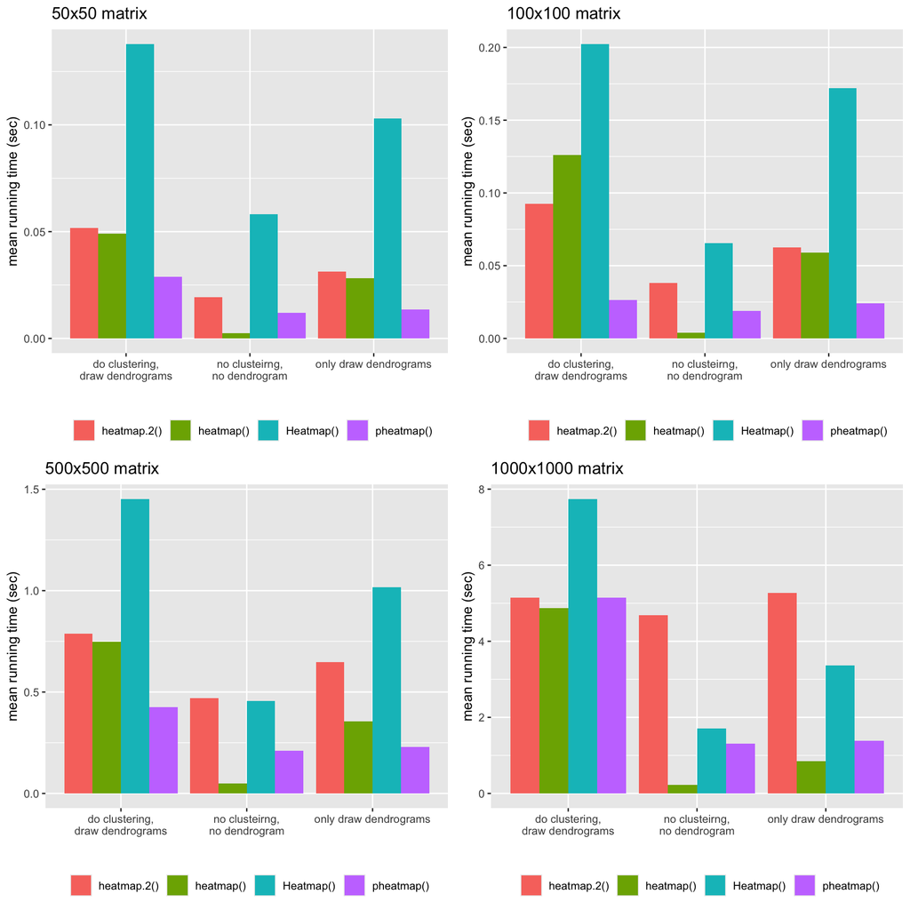